# Clustering Workbook

Welcome to the Clustering Workbook. Let’s start with importing the required libraries.

```python
import numpy as np
import pandas as pd

from matplotlib import pyplot as plt
%matplotlib inline

import seaborn as sns
sns.set_style('darkgrid')

%matplotlib notebook
```

First, let’s read the sample data set.

```python
sample_df = pd.read_csv('clustering_dataset.csv')
```

```python
sample_df.describe()
```

|  | x | y |
| --- | --- | --- |
| count | 300.000000 | 300.000000 |
| mean | 3.646046 | 2.938750 |
| std | 2.268252 | 1.840548 |
| min | -1.714843 | -0.680250 |
| 25% | 1.355996 | 1.383061 |
| 50% | 4.316122 | 2.691587 |
| 75% | 5.425505 | 4.610866 |
| max | 7.392365 | 7.598304 |

```python
sample_df.head()
```

|  | x | y |
| --- | --- | --- |
| 0 | 3.914369 | 5.642055 |
| 1 | 5.997345 | 3.022112 |
| 2 | 5.282978 | 5.712265 |
| 3 | 3.493705 | 7.598304 |
| 4 | 4.421400 | 4.975374 |

Let’s also plot the data set to try and understand how it looks like.

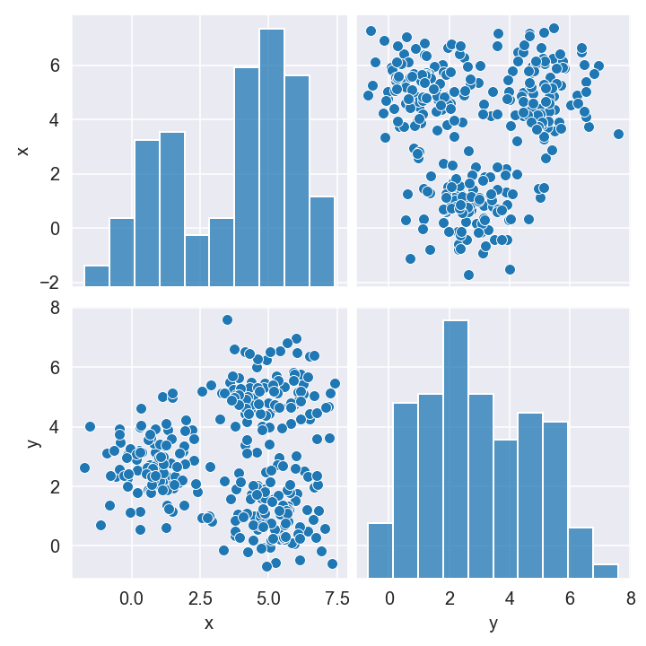

```python
sns.pairplot(data=sample_df)
```

## KMeans Clustering

First, we will explore KMeans clustering.

```python
from sklearn.cluster import KMeans
```

```python
X = sample_df
```

I will start with a case of 3 clusters.

```python
kmeans = KMeans(n_clusters=3, random_state=123)
kmeans.fit(X)
```

```
KMeans(n_clusters=3, random_state=123)
```

```python
clustered_data = sample_df.copy()#X.copy()
clustered_data['cluster'] = kmeans.predict(X)
```

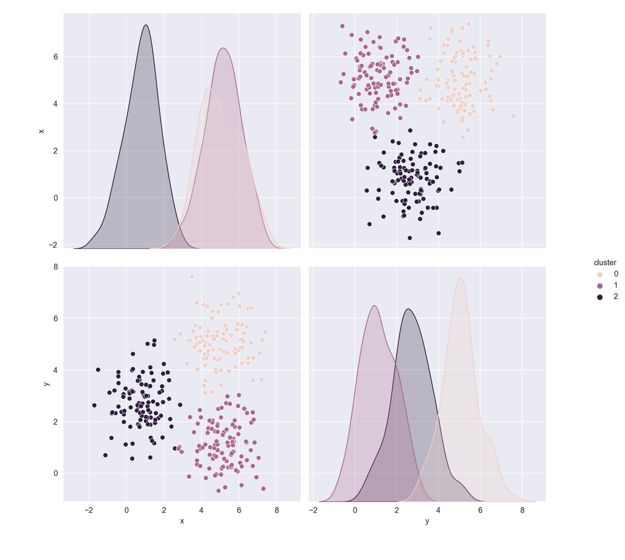

```python
sns.pairplot(data=clustered_data, hue='cluster')
```

```python
clustered_data.head()
```

|  | x | y | cluster |
| --- | --- | --- | --- |
| 0 | 3.914369 | 5.642055 | 0 |
| 1 | 5.997345 | 3.022112 | 1 |
| 2 | 5.282978 | 5.712265 | 0 |
| 3 | 3.493705 | 7.598304 | 0 |
| 4 | 4.421400 | 4.975374 | 0 |

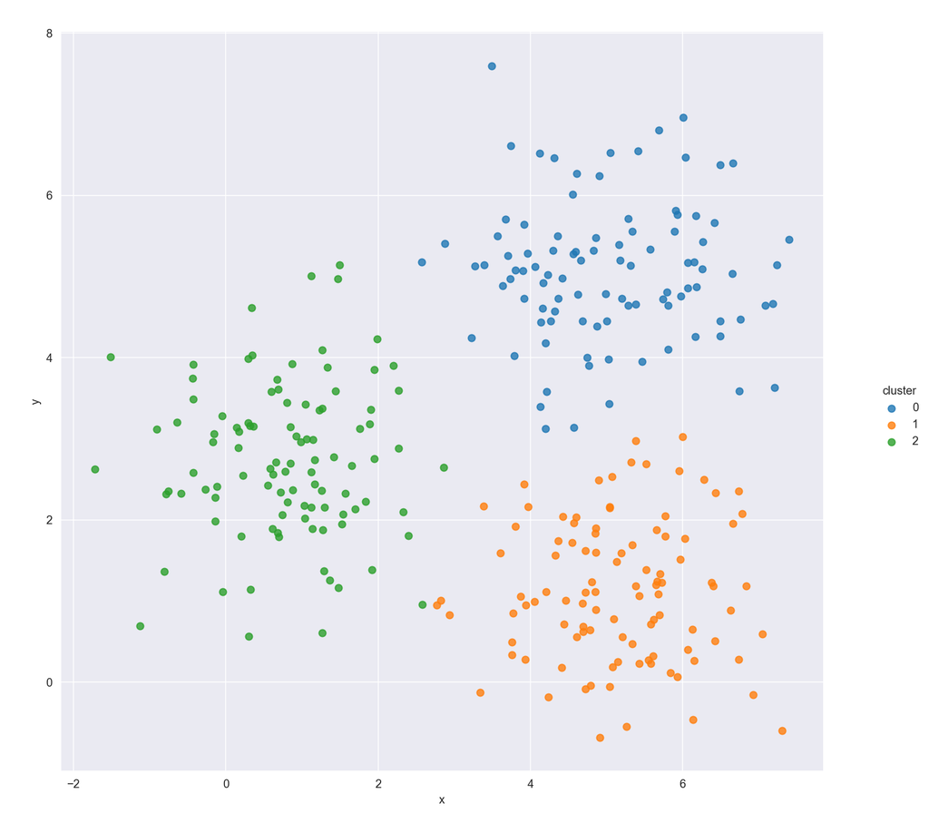

```python
# Scatterplot, colored by cluster
sns.lmplot(x='x', y='y', hue='cluster', data=clustered_data, fit_reg=False)
plt.show()
```

Is this a good clustering? What are some problematic points?

### Iteration Number

Can we go back to basics? How does the KMeans work so well? Let’s make it so that there will only be one guess.

```python
# Fit K-Means (but only allow 1 iteration)
kmeans_m1 = KMeans(n_clusters=3, random_state=123, max_iter=1)
```

```python
kmeans_m1.fit(X)
```

```
KMeans(max_iter=1, n_clusters=3, random_state=123)
```

```python
clustered_data = sample_df.copy()#X.copy()
clustered_data['cluster'] = kmeans_m1.predict(X)
```

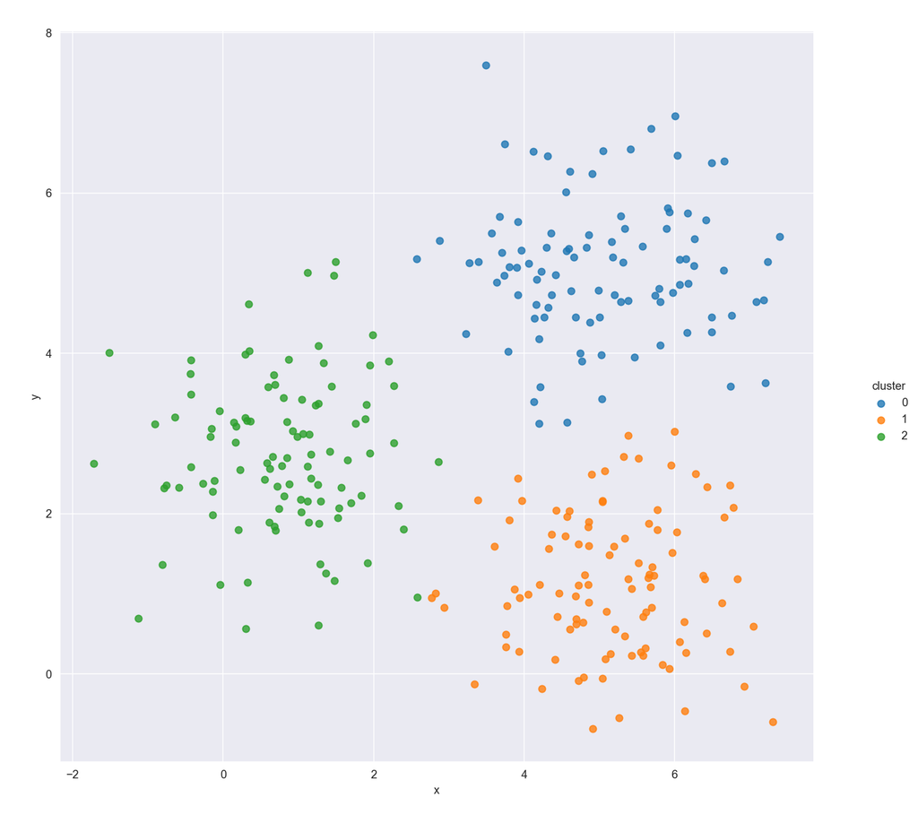

```python
# Scatterplot, colored by cluster
sns.lmplot(x='x', y='y', hue='cluster', data=clustered_data, fit_reg=False)
plt.show()
```

This is still bull’s eye at the first try. What are we missing?

```python
kmeans_m1.n_init
```

```
10
```

🤦🏻‍♀️Of course, initialization iterations.

```python
kmeans_m2 = KMeans(n_clusters=3,
                      random_state=5,
                      max_iter=1, # Only allow 1 max iteration
                      n_init=1, # Only allow 1 set of centroid starting seeds
                      init='random') # choose random initial centroids.
```

```python
kmeans_m2.fit(X)
```

```
KMeans(init='random', max_iter=1, n_clusters=3, n_init=1, random_state=5)
```

```python
clustered_data = sample_df.copy()#X.copy()
clustered_data['cluster'] = kmeans_m2.predict(X)
```

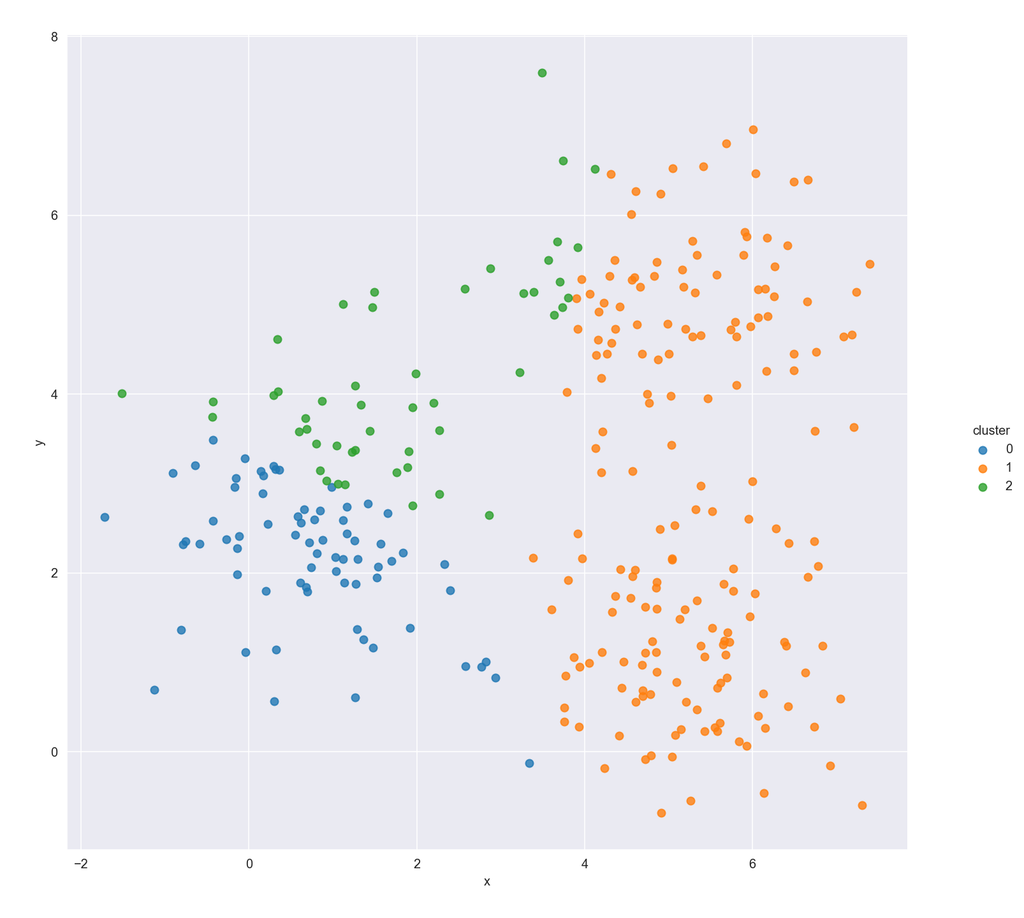

```python
# Scatterplot, colored by cluster
sns.lmplot(x='x', y='y', hue='cluster', data=clustered_data, fit_reg=False)
plt.show()
```

Not so good now. So we know, that the initialization also starts with iterations of guesses.

### Number of Clusters

Now let’s explore how different number of clusters change the result.

```python
kmeans_m3 = KMeans(n_clusters=2,
                      random_state=5,
                      max_iter=1, # Only allow 1 max iteration
                      n_init=1, # Only allow 1 set of centroid starting seeds
                      init='random') # choose random initial centroids.
```

```python
kmeans_m3.fit(X)
```

```
KMeans(init='random', max_iter=1, n_clusters=2, n_init=1, random_state=5)
```

```python
clustered_data = sample_df.copy()#X.copy()
clustered_data['cluster'] = kmeans_m3.predict(X)
```

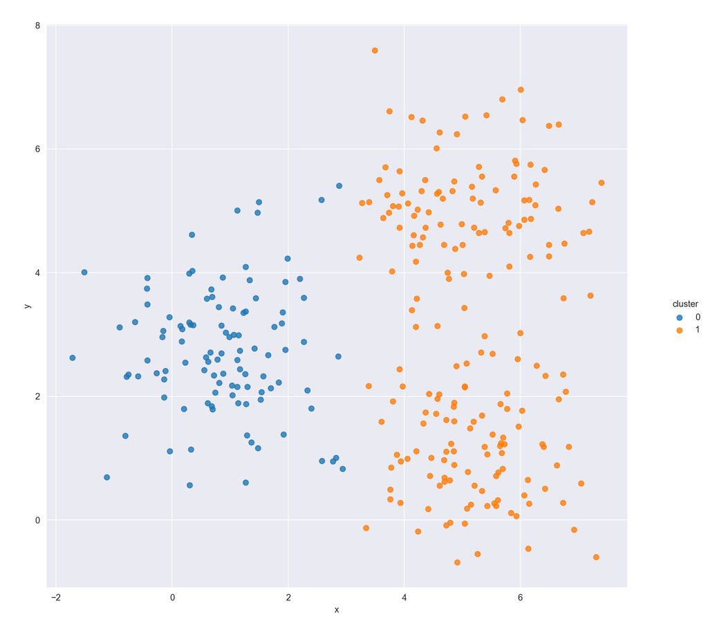

```python
# Scatterplot, colored by cluster
sns.lmplot(x='x', y='y', hue='cluster', data=clustered_data, fit_reg=False)
plt.show()
```

```python
kmeans_m4 = KMeans(n_clusters=12,
                      random_state=5,
                      max_iter=1, # Only allow 1 max iteration
                      n_init=1, # Only allow 1 set of centroid starting seeds
                      init='random') # choose random initial centroids.
```

```python
kmeans_m4.fit(X)
```

```
KMeans(init='random', max_iter=1, n_clusters=12, n_init=1, random_state=5)
```

```python
clustered_data = sample_df.copy()#X.copy()
clustered_data['cluster'] = kmeans_m4.predict(X)
```

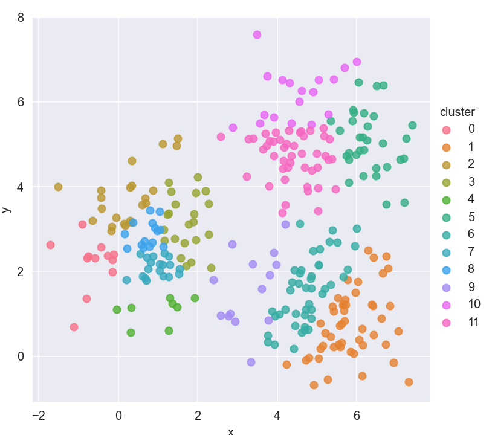

```python
# Scatterplot, colored by cluster
sns.lmplot(x='x', y='y', hue='cluster', data=clustered_data, fit_reg=False)
plt.show()
```

May be a bit too much.

### MiniBatch KMeans

```python
from sklearn.cluster import MiniBatchKMeans
```

```python
mini_kmeans = MiniBatchKMeans(n_clusters=3)
```

```python
mini_kmeans.fit(X)
```

```
MiniBatchKMeans(n_clusters=3)
```

```python
clustered_data = sample_df.copy()#X.copy()
clustered_data['cluster'] = mini_kmeans.predict(X)
```

[figure not shown]

```python
# Scatterplot, colored by cluster
sns.lmplot(x='x', y='y', hue='cluster', data=clustered_data, fit_reg=False)
plt.show()
```

## Evaluation Criteria

It is hard to understand this by looking. Let’s explore some popular evaluation metrics for clustering.

### Inertia

```python
mini_kmeans.inertia_
```

```
535.9649514948377
```

```python
kmeans_m4.inertia_
```

```
236.99001505632006
```

```python
def fit_kmeans_model(n_clusters, X):
    model = KMeans(n_clusters=n_clusters,
                      random_state=5,
                      max_iter=1, # Only allow 1 max iteration
                      n_init=1, # Only allow 1 set of centroid starting seeds
                      init='random') # choose random initial centroids.
    model.fit(X)

    clustered_data = sample_df.copy()
    clustered_data['cluster'] = model.predict(X)

    return (clustered_data, model)
```

[figure not shown]

```python
fig = plt.figure(figsize=[6,4])
ax = plt.subplot(111)

for n in range(2,50):
    clustered_data, model = fit_kmeans_model(n, X)
    ax.scatter(n, model.inertia_, color='b')
```

There are thre performance intervals here.

```python
clustered_data, model = fit_kmeans_model(6, X)
```

[figure not shown]

```python
# Scatterplot, colored by cluster
sns.lmplot(x='x', y='y', hue='cluster', data=clustered_data, fit_reg=False)
plt.show()
```

### Silhouette Score

Now let’s see what the silhouette score would tell for the model performance.

```python
from sklearn.metrics import silhouette_score
```

```python
silhouette_score(X, model.labels_)
```

```
0.42357623891927415
```

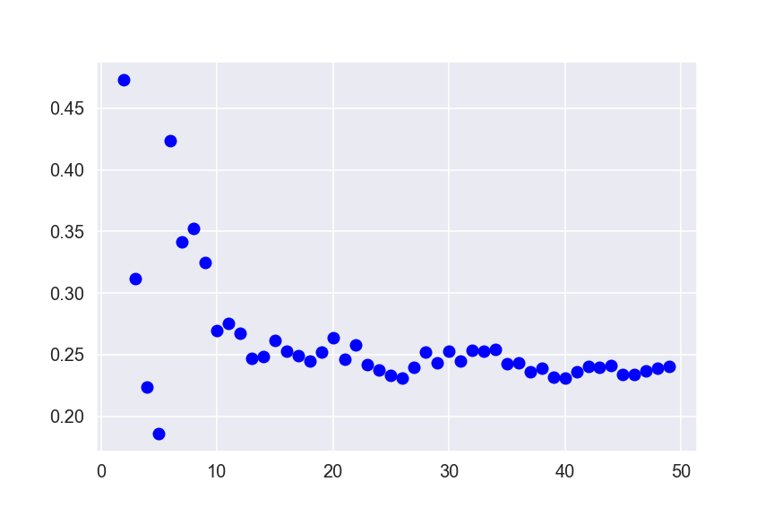

```python
fig = plt.figure(figsize=[6,4])
ax = plt.subplot(111)

for n in range(2,50):
    clustered_data, model = fit_kmeans_model(n, X)
    ax.scatter(n, silhouette_score(X, model.labels_),color='b')
```

The second highest value is 6.

### KMeans Failure

We have seen that KMeans is doing okay with the data set we have looked at so far.

```python
from sklearn.datasets import make_moons
```

```python
X, y = make_moons(n_samples=300, noise=0.08, random_state=0)
```

```python
kmeans = KMeans(n_clusters=2)
```

```python
kmeans.fit(X)
```

```
KMeans(n_clusters=2)
```

```python
y_pred=kmeans.predict(X)
```

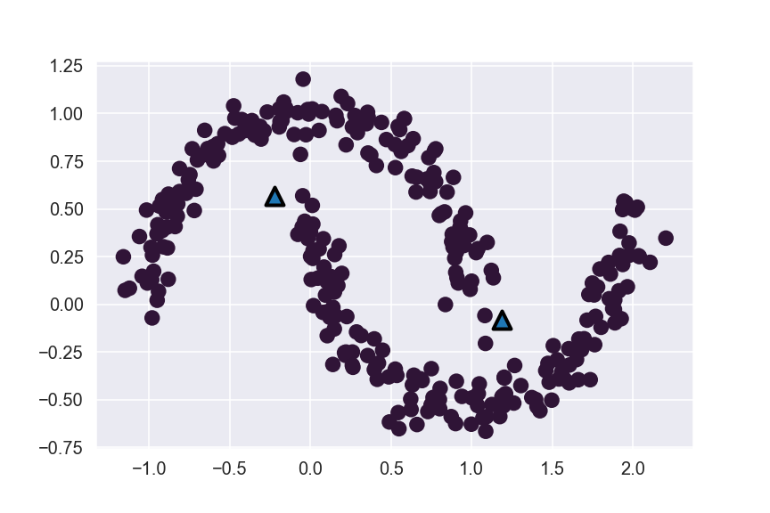

```python
fig = plt.figure(figsize=[6,4])
ax = plt.subplot(111)

ax.scatter(X[:,0], X[:,1], c=y_pred, cmap='twilight_shifted', s=60)
ax.scatter(kmeans.cluster_centers_[:,0], kmeans.cluster_centers_[:,1], marker='^', s=100, linewidth=2, edgecolor='k')
```

```python
kmeans = KMeans(n_clusters=3)
kmeans.fit(X)
y_pred=kmeans.predict(X)
```

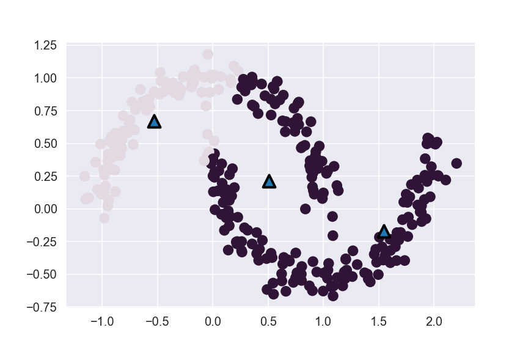

```python
fig = plt.figure(figsize=[6,4])
ax = plt.subplot(111)

ax.scatter(X[:,0], X[:,1], c=y_pred, cmap='twilight_shifted', s=60)
ax.scatter(kmeans.cluster_centers_[:,0], kmeans.cluster_centers_[:,1], marker='^', s=100, linewidth=2, edgecolor='k')
```

```python
kmeans = KMeans(n_clusters=3, max_iter=100)
kmeans.fit(X)
y_pred=kmeans.predict(X)
```

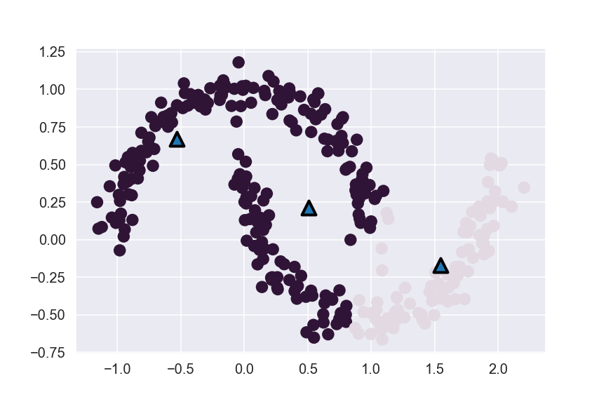

```python
fig = plt.figure(figsize=[6,4])
ax = plt.subplot(111)

ax.scatter(X[:,0], X[:,1], c=y_pred, cmap='twilight_shifted', s=60)
ax.scatter(kmeans.cluster_centers_[:,0], kmeans.cluster_centers_[:,1], marker='^', s=100, linewidth=2, edgecolor='k')
```

```python
kmeans = KMeans(n_clusters=12)
kmeans.fit(X)
y_pred=kmeans.predict(X)
```

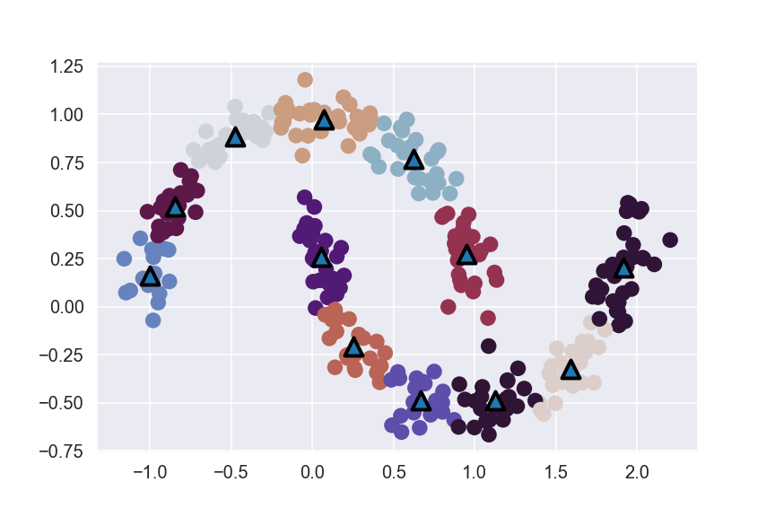

```python
fig = plt.figure(figsize=[6,4])
ax = plt.subplot(111)

ax.scatter(X[:,0], X[:,1], c=y_pred, cmap='twilight_shifted', s=60)
ax.scatter(kmeans.cluster_centers_[:,0], kmeans.cluster_centers_[:,1], marker='^', s=100, linewidth=2, edgecolor='k')
```

Not getting any better.

## DBSCAN

```python
from sklearn.cluster import DBSCAN
from sklearn.preprocessing import StandardScaler
```

```python
dbscan = DBSCAN(eps=0.3)
```

DBSCAN requires scaling. When we are training a model from scratch, we will always scale+train.

```python
scaler = StandardScaler()
scaler.fit(X)
X_scaled = scaler.transform(X)
```

```python
clusters = dbscan.fit_predict(X_scaled)
```

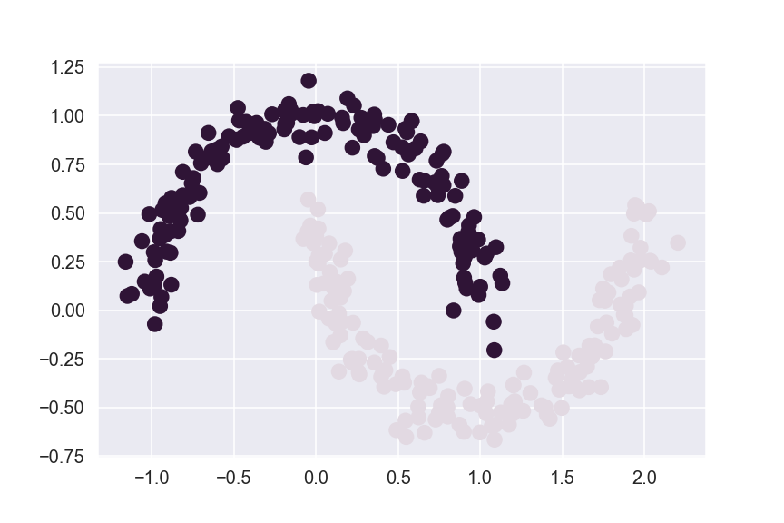

```python
fig = plt.figure(figsize=[6,4])
ax = plt.subplot(111)

ax.scatter(X[:,0], X[:,1], c=clusters, s=60, cmap='twilight_shifted')
```

Pretty good!

```python
silhouette_score(X_scaled, clusters)
```

```
0.38135450723457787
```

```python
def fit_dbscan(eps):
    dbscan = DBSCAN(eps=eps)
    clusters = dbscan.fit_predict(X_scaled)
    return clusters
```

```python
eps_list = list(np.arange(0.1,0.35,0.01))
```

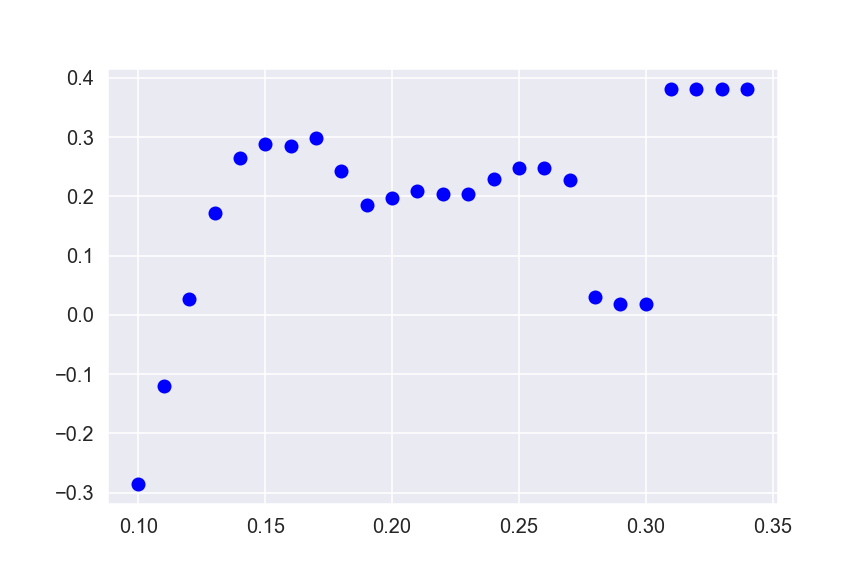

```python
fig = plt.figure(figsize=[6,4])
ax = plt.subplot(111)

for eps in (eps_list):
    clusters = fit_dbscan(eps)
    ax.scatter(eps, silhouette_score(X_scaled, clusters), color='b')
```

DBSCAN does not have inertia, that’s why we are only using silhouette score here.  
👏 Congratulations, you have completed the Clustering Workbook!